# Chapter 7 - exercise 2: Absenteeism_at_work

### Cho dữ liệu Absenteeism_at_work trong tập tin Absenteeism_at_work.csv

### Yêu cầu: Hãy đọc dữ liệu từ tập tin này, áp dụng Random Forest để thực hiện việc xác định thời gian vắng mặt theo giờ (Absenteeism time in hours (target)) dựa trên các thông tin được cung cấp.

#### Chi tiết:

1. Đọc dữ liệu. Chuẩn hóa dữ liệu
2. Tạo X_train, X_test, y_train, y_test từ dữ liệu chuẩn hóa với tỷ lệ dữ liệu test là 0.3
3. Áp dụng Random Forest, Tìm kết quả
4. Kiểm tra độ chính xác
5. Tìm các thuộc tính quan trọng nhất trong tập dữ liệu
6. Trực quan hóa thuộc tính quan trọng
7. Áp dụng lại Random Forest dựa trên các thuộc tính quan trọng, tìm kết quả
8. Kiểm tra độ chính xác
9. Tự cho 1 dữ liệu X_test mới. Ví dụ như: ['Reason for absence', 'Work load Average per day', 'Age',

   ```
   'Month of absence', 'Day of the week', 'Hit target',
   'Transportation expense', 'Weight', 'Seasons', 'Height',
   'Distance from Residence to Work', 'Son', 'Pet', 'Service time'] ứng với [ 10., 205.917, 28.,8., 4., 92., 330. ,
    84., 1., 182., 16., 0., 0., 4.]. Tìm kết quả Y test.
   ```

### Attribute Information:

1. Individual identification (ID)
2. Reason for absence (ICD). Absences attested by the International Code of Diseases (ICD) stratified into 21 categories (I to XXI) as follows:
- I Certain infectious and parasitic diseases
- II Neoplasms
- III Diseases of the blood and blood-forming organs and certain disorders involving the immune mechanism
- IV Endocrine, nutritional and metabolic diseases
- V Mental and behavioural disorders
- VI Diseases of the nervous system
- VII Diseases of the eye and adnexa
- VIII Diseases of the ear and mastoid process
- IX Diseases of the circulatory system
- X Diseases of the respiratory system
- XI Diseases of the digestive system
- XII Diseases of the skin and subcutaneous tissue
- XIII Diseases of the musculoskeletal system and connective tissue
- XIV Diseases of the genitourinary system
- XV Pregnancy, childbirth and the puerperium
- XVI Certain conditions originating in the perinatal period
- XVII Congenital malformations, deformations and chromosomal abnormalities
- XVIII Symptoms, signs and abnormal clinical and laboratory findings, not elsewhere classified
- XIX Injury, poisoning and certain other consequences of external causes
- XX External causes of morbidity and mortality
- XXI Factors influencing health status and contact with health services.

And 7 categories without (CID) patient follow-up (22), medical consultation (23), blood donation (24), laboratory examination (25), unjustified absence (26), physiotherapy (27), dental consultation (28).

1. Month of absence
2. Day of the week (Monday (2), Tuesday (3), Wednesday (4), Thursday (5), Friday (6))
3. Seasons (summer (1), autumn (2), winter (3), spring (4))
4. Transportation expense
5. Distance from Residence to Work (kilometers)
6. Service time
7. Age
8. Work load Average/day
9. Hit target
10. Disciplinary failure (yes=1; no=0)
11. Education (high school (1), graduate (2), postgraduate (3), master and doctor (4))
12. Son (number of children)
13. Social drinker (yes=1; no=0)
14. Social smoker (yes=1; no=0)
15. Pet (number of pet)
16. Weight
17. Height
18. Body mass index
19. Absenteeism time in hours (target)

```python
from google.colab import drive
drive.mount("/content/gdrive", force_remount=True)

path = '/content/gdrive/My Drive/LDS6_MachineLearning/'
```

```python
import numpy as np
import pandas as pd
import matplotlib.pyplot as plt
from sklearn.model_selection import train_test_split
import math
```

```python
data = pd.read_csv(path + "practice/Chapter7_Random_Forest/Absenteeism_at_work.csv", sep=";")
```

```python
type(data)
```

```
pandas.core.frame.DataFrame
```

```python
data.info()
```

```
<class 'pandas.core.frame.DataFrame'>
RangeIndex: 740 entries, 0 to 739
Data columns (total 21 columns):
ID                                 740 non-null int64
Reason for absence                 740 non-null int64
Month of absence                   740 non-null int64
Day of the week                    740 non-null int64
Seasons                            740 non-null int64
Transportation expense             740 non-null int64
Distance from Residence to Work    740 non-null int64
Service time                       740 non-null int64
Age                                740 non-null int64
Work load Average per day          740 non-null float64
Hit target                         740 non-null int64
Disciplinary failure               740 non-null int64
Education                          740 non-null int64
Son                                740 non-null int64
Social drinker                     740 non-null int64
Social smoker                      740 non-null int64
Pet                                740 non-null int64
Weight                             740 non-null int64
Height                             740 non-null int64
Body mass index                    740 non-null int64
Absenteeism time in hours          740 non-null int64
dtypes: float64(1), int64(20)
memory usage: 121.5 KB
```

```python
data.head()
```

|  | ID | Reason for absence | Month of absence | Day of the week | Seasons | Transportation expense | Distance from Residence to Work | Service time | Age | Work load Average per day | Hit target | Disciplinary failure | Education | Son | Social drinker | Social smoker | Pet | Weight | Height | Body mass index | Absenteeism time in hours |
| --- | --- | --- | --- | --- | --- | --- | --- | --- | --- | --- | --- | --- | --- | --- | --- | --- | --- | --- | --- | --- | --- |
| 0 | 11 | 26 | 7 | 3 | 1 | 289 | 36 | 13 | 33 | 239.554 | 97 | 0 | 1 | 2 | 1 | 0 | 1 | 90 | 172 | 30 | 4 |
| 1 | 36 | 0 | 7 | 3 | 1 | 118 | 13 | 18 | 50 | 239.554 | 97 | 1 | 1 | 1 | 1 | 0 | 0 | 98 | 178 | 31 | 0 |
| 2 | 3 | 23 | 7 | 4 | 1 | 179 | 51 | 18 | 38 | 239.554 | 97 | 0 | 1 | 0 | 1 | 0 | 0 | 89 | 170 | 31 | 2 |
| 3 | 7 | 7 | 7 | 5 | 1 | 279 | 5 | 14 | 39 | 239.554 | 97 | 0 | 1 | 2 | 1 | 1 | 0 | 68 | 168 | 24 | 4 |
| 4 | 11 | 23 | 7 | 5 | 1 | 289 | 36 | 13 | 33 | 239.554 | 97 | 0 | 1 | 2 | 1 | 0 | 1 | 90 | 172 | 30 | 2 |

```python
data.tail()
```

|  | ID | Reason for absence | Month of absence | Day of the week | Seasons | Transportation expense | Distance from Residence to Work | Service time | Age | Work load Average per day | Hit target | Disciplinary failure | Education | Son | Social drinker | Social smoker | Pet | Weight | Height | Body mass index | Absenteeism time in hours |
| --- | --- | --- | --- | --- | --- | --- | --- | --- | --- | --- | --- | --- | --- | --- | --- | --- | --- | --- | --- | --- | --- |
| 735 | 11 | 14 | 7 | 3 | 1 | 289 | 36 | 13 | 33 | 264.604 | 93 | 0 | 1 | 2 | 1 | 0 | 1 | 90 | 172 | 30 | 8 |
| 736 | 1 | 11 | 7 | 3 | 1 | 235 | 11 | 14 | 37 | 264.604 | 93 | 0 | 3 | 1 | 0 | 0 | 1 | 88 | 172 | 29 | 4 |
| 737 | 4 | 0 | 0 | 3 | 1 | 118 | 14 | 13 | 40 | 271.219 | 95 | 0 | 1 | 1 | 1 | 0 | 8 | 98 | 170 | 34 | 0 |
| 738 | 8 | 0 | 0 | 4 | 2 | 231 | 35 | 14 | 39 | 271.219 | 95 | 0 | 1 | 2 | 1 | 0 | 2 | 100 | 170 | 35 | 0 |
| 739 | 35 | 0 | 0 | 6 | 3 | 179 | 45 | 14 | 53 | 271.219 | 95 | 0 | 1 | 1 | 0 | 0 | 1 | 77 | 175 | 25 | 0 |

```python
X = data.iloc[:, 1:-1]
y = data.iloc[:,-1]
```

```python
X.head()
```

|  | Reason for absence | Month of absence | Day of the week | Seasons | Transportation expense | Distance from Residence to Work | Service time | Age | Work load Average per day | Hit target | Disciplinary failure | Education | Son | Social drinker | Social smoker | Pet | Weight | Height | Body mass index |
| --- | --- | --- | --- | --- | --- | --- | --- | --- | --- | --- | --- | --- | --- | --- | --- | --- | --- | --- | --- |
| 0 | 26 | 7 | 3 | 1 | 289 | 36 | 13 | 33 | 239.554 | 97 | 0 | 1 | 2 | 1 | 0 | 1 | 90 | 172 | 30 |
| 1 | 0 | 7 | 3 | 1 | 118 | 13 | 18 | 50 | 239.554 | 97 | 1 | 1 | 1 | 1 | 0 | 0 | 98 | 178 | 31 |
| 2 | 23 | 7 | 4 | 1 | 179 | 51 | 18 | 38 | 239.554 | 97 | 0 | 1 | 0 | 1 | 0 | 0 | 89 | 170 | 31 |
| 3 | 7 | 7 | 5 | 1 | 279 | 5 | 14 | 39 | 239.554 | 97 | 0 | 1 | 2 | 1 | 1 | 0 | 68 | 168 | 24 |
| 4 | 23 | 7 | 5 | 1 | 289 | 36 | 13 | 33 | 239.554 | 97 | 0 | 1 | 2 | 1 | 0 | 1 | 90 | 172 | 30 |

```python
y.head()
```

```
0    4
1    0
2    2
3    4
4    2
Name: Absenteeism time in hours, dtype: int64
```

```python
# Import train_test_split function
from sklearn.model_selection import train_test_split
# Split dataset into training set and test set
X_train, X_test, y_train, y_test = train_test_split(X, y,
                                                    test_size=0.3,
                                                    random_state = 1)
```

```python
from sklearn.ensemble import RandomForestRegressor
```

```python
clf=RandomForestRegressor(n_estimators=250)
```

```python
clf.fit(X_train,y_train)
y_pred = clf.predict(X_test)
```

```python
type(y_test)
```

```
pandas.core.series.Series
```

```python
type(y_pred)
```

```
numpy.ndarray
```

```python
from sklearn import metrics
print("Mean Squared Error:", metrics.mean_squared_error(y_test, y_pred))
```

```
Mean Squared Error: 140.16595826074104
```

```python
# Evaluation
print("The R^2: ",clf.score(X,y)*100,"%")
print("The Training R^2 is: ",clf.score(X_train,y_train)*100,"%")
print("The Testing R^2 is: ",clf.score(X_test,y_test)*100,"%")
```

```
The R^2:  65.15575387930302 %
The Training R^2 is:  84.1366570619855 %
The Testing R^2 is:  20.21904745550612 %
```

```python
# => The Training  R^2 >> Testing R^2 => Overfitting => Solution???
```

```python
# Finding Important Features in Scikit-learn
import pandas as pd
feature_imp = pd.Series(clf.feature_importances_, index = np.array(X.columns)).sort_values(ascending=False)
feature_imp
```

```
Reason for absence                 0.232101
Work load Average per day          0.171391
Age                                0.092525
Month of absence                   0.081933
Hit target                         0.065565
Day of the week                    0.063406
Transportation expense             0.052554
Height                             0.036078
Seasons                            0.035613
Son                                0.035388
Weight                             0.034936
Distance from Residence to Work    0.028406
Service time                       0.017211
Pet                                0.016679
Body mass index                    0.016579
Social drinker                     0.012307
Social smoker                      0.003139
Education                          0.002797
Disciplinary failure               0.001391
dtype: float64
```

```python
type(feature_imp)
```

```
pandas.core.series.Series
```

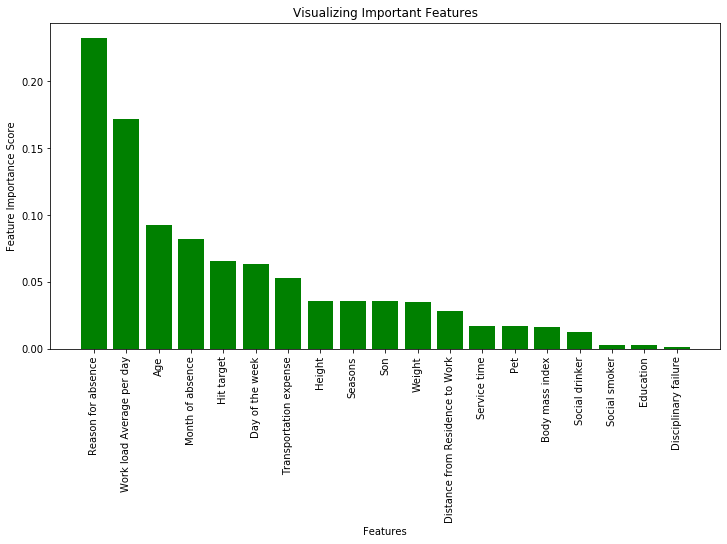

```python
import matplotlib.pyplot as plt
%matplotlib inline
# Creating a bar plot
plt.figure(figsize=(12,6))
plt.bar(feature_imp.index, feature_imp, color="g")
# Add labels to your graph
plt.xlabel('Features')
plt.ylabel('Feature Importance Score')
plt.title("Visualizing Important Features")
plt.xticks(rotation = "vertical")
plt.show()
```

```python
feature_imp[feature_imp >0.05].sum()
```

```
0.7594755095886327
```

```python
feature_imp_select = feature_imp[feature_imp >0.05]
feature_imp_select
```

```
Reason for absence           0.232101
Work load Average per day    0.171391
Age                          0.092525
Month of absence             0.081933
Hit target                   0.065565
Day of the week              0.063406
Transportation expense       0.052554
dtype: float64
```

```python
feature_imp_select.index
```

```
Index(['Reason for absence', 'Work load Average per day', 'Age',
       'Month of absence', 'Hit target', 'Day of the week',
       'Transportation expense'],
      dtype='object')
```

```python
# Tạo lại dữ liệu huấn luyện và test sau khi bỏ đi các thuộc tính ít quan trọng hơn
# Split dataset into features and labels
X1 = data[feature_imp_select.index]
y1 = data['Absenteeism time in hours']
```

```python
# Split dataset into training set and test set
X1_train, X1_test, y1_train, y1_test = train_test_split(X1, y1,
                                                        test_size=0.3,
                                                        random_state = 1)
```

```python
clf1=RandomForestRegressor(n_estimators=100)
clf1.fit(X1_train,y1_train)

y1_pred=clf1.predict(X1_test)
```

```python
print("Mean Squared Error:", metrics.mean_squared_error(y1_test, y1_pred))
```

```
Mean Squared Error: 141.85117864682962
```

```python
# Evaluation
print("The R^2: ",clf1.score(X1,y1)*100,"%")
print("The Training R^2: ",clf1.score(X1_train,y1_train)*100,"%")
print("The Testing R^2: ",clf1.score(X1_test,y1_test)*100,"%")
```

```
The R^2:  63.908978166542596 %
The Training R^2:  82.76824170015401 %
The Testing R^2:  19.25983817732003 %
```

```python
# => The Training  R^2 >> Testing R^2 => Overfitting => Solution???
```

```python
a = X1.iloc[20]
X_new = a.values
```

```python
clf1.predict([X_new])
```

```
array([17.02])
```